# 2008 Loan Crisis - Monte Carlo method

From Dario Abadie translated by Marcelo Marotta

# O que é o método de Monte Carlo?

O termo “Método de Monte Carlo” surgiu no laboratório nacional de Los Alamos (EUA), no final dos anos 1940, durante o desenvolvimento de uma bomba atômica (Metropolis e Ulam, 1949). O termo “Monte Carlo” faz referência à cidade famosa por seus cassinos, que fazem uso de mecanismos “aleatórios” para jogos. O desenvolvimento destes métodos também contribuíram fortemente para o desenvolvimento dos primeiros computadores eletrônicos, acelarando a computação de tarefas numéricas repetitivas.

Não existe um consenso em como os métodos de Monte Carlo poderiam ser definidos, mas algumas distinções podem ser feitas:

Simulação: Sortear um valor de uma U(0,1) pode simular o lançamento de uma moeda: se for menor do que 0.5, atribua cara, caso contrário, coroa.

Método de Monte Carlo: Derramar uma caixa de moedas em uma mesa e calcular a proporção de moedas que caem cara ou coroa.

Simulação de Monte Carlo: Sortear um grande número de valores de uma U(0,1) e atribuir cara (menor que 0.5) ou coroa.

## Os métodos de Monte Carlo também podem ser divididos em duas categorias:

- Integração de Monte Carlo : quando utilizado para resolver problemas de integração numérica
- Simulação de Monte Carlo : quando utilizado para resolver problemas mais gerais através de simulação

# Introdução - Projeto de análise de empréstimos

Neste projeto vamos analisar a crise de 2008 provocada pelos bancos e seus empréstimos. Começaremos com algumas suposições simples e gradualmente adicionaremos mais variáveis ao nosso modelo para obter conclusões interessantes sobre quanto dinheiro o banco perde e como evitá-lo usando a probabilidade e o método de Monte Carlo.

# Premissas

- Loan (Empréstimos) = $180.000
- Default rate (taxa padrão) = 2% (Pessoas que não podem devolver o dinheiro ao banco)
- Default loss (perda padrão) = $200.000
- Number of loans (número de empréstimos) : 10000
- Esses números são figurativos para fins de aprendizagem

# Quanto dinheiro o banco perde devido à inadimplência?

Primeiro, vamos calcular matematicamente a quantidade de dinheiro que o banco perde devido à inadimplência, supondo uma taxa de juros de ** 0% ** (O banco empresta dinheiro de graça!). Podemos calcular essa perda de dinheiro como
$$Loss = n_{loans} * default_{rate} *default_{loss}$$

$$Loss = 10000 * 0.02 *200000$$

$$Loss =40000000$$

Parece bastante simples, certo? Agora vamos ver se podemos calcular esse resultado usando o método Monte Carlo. Embora possa parecer inútil realizar esta simulação para encontrar um resultado que obtivemos com uma equação simples, é necessário mostrar como esta técnica funciona (veremos como ela é útil nas próximas seções). Se não estiver familiarizado com este método, sugiro que você visite este [post] (https://towardsdatascience.com/the-house-always-wins-monte-carlo-simulation-eb82787da2a3). Basicamente, este método consiste em repetir várias vezes um processo cujo resultado é aleatório para definir quantitativamente a probabilidade de ocorrência de um evento.

No código abaixo, usamos a função * sample() * para escolher aleatoriamente um elemento de uma matriz (neste caso * padrão * ou * não padrão *) de acordo com as probailidades previamente definidas. Isso representa o caso de uma pessoa que recebeu um empréstimo, que pode ou não devolver o dinheiro ao banco. O tamanho da matriz representa a quantidade de pessoas que receberam empréstimos. Assim que tivermos os resultados de todos os clientes (reembolsados ou não reembolsados) passamos a somar todas as perdas (lembre-se que neste exemplo o banco não cobra taxa de juros) e obtemos o lucro do banco para este cenário. Isso nos dá uma ideia de quanto dinheiro o banco perderia devido à inadimplência. Indo um passo à frente, o que acontece se recriarmos este cenário 1000 vezes e calcularmos o lucro médio? Obtemos uma ideia melhor e mais precisa de quanto perderia o dinheiro. Este é o Método de Monte Carlo.

```
## [1] "Calculated result: "
```

```
## [1] -4e+07
```

```
## [1] "Monte Carlo result: "
```

```
## [1] -40061600
```

Muito semelhante, certo? Vamos visualizar o histograma dos resultados.

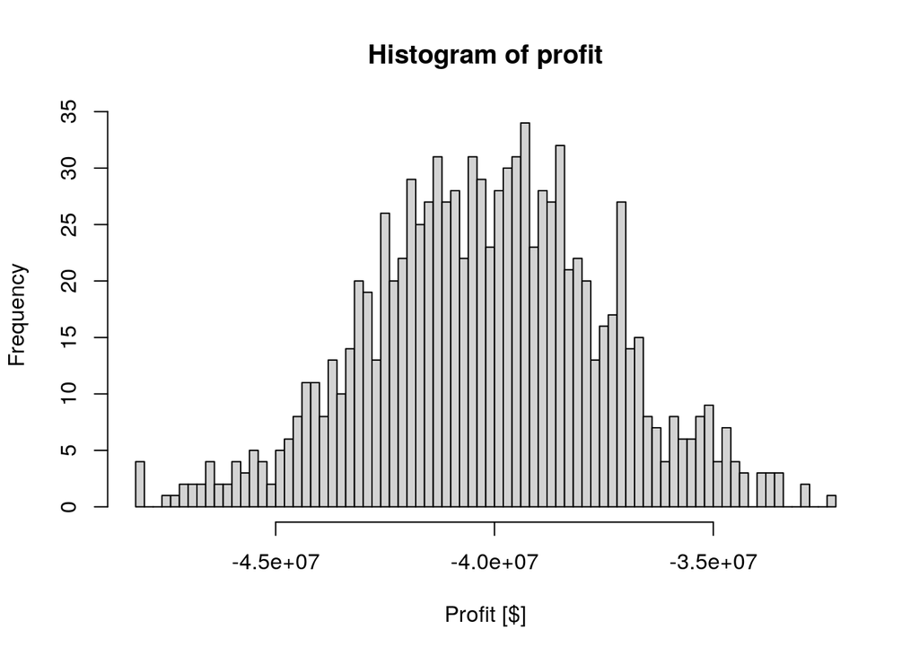

Podemos avaliar como, em média, o banco perde cerca de 40 milhões com uma taxa de juros de 0%. Essa situação nos leva à próxima pergunta.

# Qual é a taxa de juros que garante que o banco não perderá dinheiro?

A próxima fórmula mostra a relação entre ganhos e perdas concedidos por empréstimos:

$$Gain * (1 - default_{rate}) - default_{loss} * default_{rate} = Profit$$

Isso significa que os ganhos provenientes das pessoas que pagaram o empréstimo, mais juros, menos o valor perdido com a inadimplência, representam o lucro do banco. No entanto, como neste caso queremos apenas não perder dinheiro, o lucro deve ser igual a 0.

$$Gain * (1 - default_{rate}) - default_{loss} * default_{rate} = 0\$$$

Então

$$Gain= \frac{default_{loss} * default_{rate}}{ (1 - default_{rate})}$$

Depois de calcularmos o ganho, a taxa de juros é obtida por:

$$I = \frac{Gain}{Loan}$$

Vamos ver se podemos calcular isso usando o método Monte Carlo.

```
## [1] "Computed interest:"
```

```
## [1] 0.023
```

```
## [1] "Calculated interest:"
```

```
## [1] 0.02267574
```

Novamente, bastante semelhante! Podemos ver como o método de Monte Carlo é eficaz. Vamos visualizar o retorno do banco com uma taxa de juros de 2,3%.

```
## [1] 0.432
```

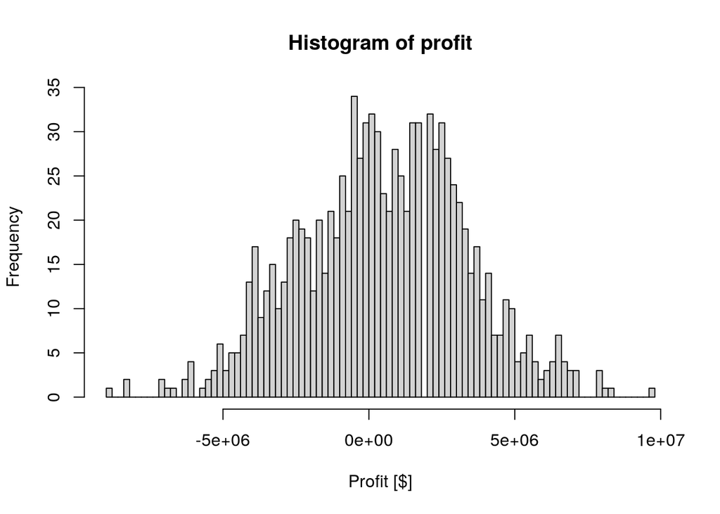

# Qual é a taxa de juros que oferece uma chance de perda de dinheiro menor que 5%?

Queremos que a probabilidade de perder dinheiro seja inferior a 5%.

$$P(S<0) <= 0.05$$

Para continuar com nossos cálculos, é possível presumir que S é um ** normalmente distribuído **, de acordo com o teorema do Limite Central.

Supondo que S seja normalmente distribuído, podemos usar ** Padronização **. A padronização de uma variável aleatória normalmente distribuída nos permite determinar com facilidade a probabilidade associada a uma faixa de valores usando uma tabela de distribuição padronizada (tabela Z). Uma variável aleatória normalmente distribuída pode ser padronizada usando esta fórmula:
$$z = \frac{x-\mu}{\sigma}$$
onde $z$ representa a variável aleatória padronizada, $x$ é o valor que está sendo padronizado, $\mu$ a média da distribuição e $\sigma$ o desvio padrão da distribuição.

A aplicação dessa técnica à nossa fórmula fica assim:

$$P(\frac{S-\mu}{\sigma}<\frac{0-\mu}{\sigma})$$
então
$$P(z <\frac{-\mu}{\sigma})$$

Quando trabalhamos com uma distribuição padronizada, a probabilidade de $z <a$ pode ser encontrada em uma ** Tabela Z **. Procuramos o valor** “a” ** e o número associado a ** “a” ** é a probabilidade de z <a. De volta ao nosso exercício, sabemos que a probabilidade é 0,05, então precisamos encontrar nosso ** “a”. ** De acordo com a tabela Z, o valor associado a esta probabilidade (0,05) é ** - 1,64 **.

Resumindo:

$$a = -1.64$$

e

então

$$-1,64 = \frac{-\mu}{\sigma}$$

$$\mu = [default_{Loss} * default_{rate} + Gain * (1 - default_{rate})] * n$$

onde $ n $ é o número de empréstimos. Substituindo na fórmula anterior, obtemos:

$$-1,64 = \frac{-[default_{Loss} * default_{rate} + Gain * (1 - default_{rate})] * n}{|Gain - default_{Loss}| * \sqrt{n*default_{rate}*(1 - default_{rate})}}$$

Então

$$Gain = \frac {default_{Loss}* default_{rate} *n-(-1,64)*\sqrt{n*default_{rate} *(1-default_{rate} )}}{n*(1-default_{rate})+(-1,64)*\sqrt{n*default_{rate} *(1-default_{rate} )}}$$

e finalmente

$$I = \frac {Gain}{Loan}$$

Nós o calculamos na próxima parte do código:

```
## [1] "Calculated interest:"
```

```
## [1] 0.02533828
```

Até o momento obtivemos uma taxa de juros de ** 0,025 **, o que garante que o banco tenha apenas 5% de chances de perder dinheiro. Agora vamos tentar obter essa taxa usando Monte Carlo.

```
## [1] "Computed interest: "
```

```
## [1] 0.026
```

Os juros calculados são ** 0,026 **. Lembra dos juros calculados? Foi** 0,0253 **, portanto podemos afirmar que os dois métodos forneceram, aproximadamente, o mesmo resultado. Para obter uma melhor aproximação, reduzimos o tamanho do passo na taxa de juros (passos de + 0,01% em vez de passos de 0,1%). Como consequência, a quantidade de iterações aumenta.

```
## [1] "Computed interest: "
```

```
## [1] 0.0255
```

Agora ambos os resultados (Calculado e Computado) combinam perfeitamente! Este é um exemplo preciso da compensação entre ** precisão ** e uso de ** recursos do computador **.

Vamos visualizar esses resultados.

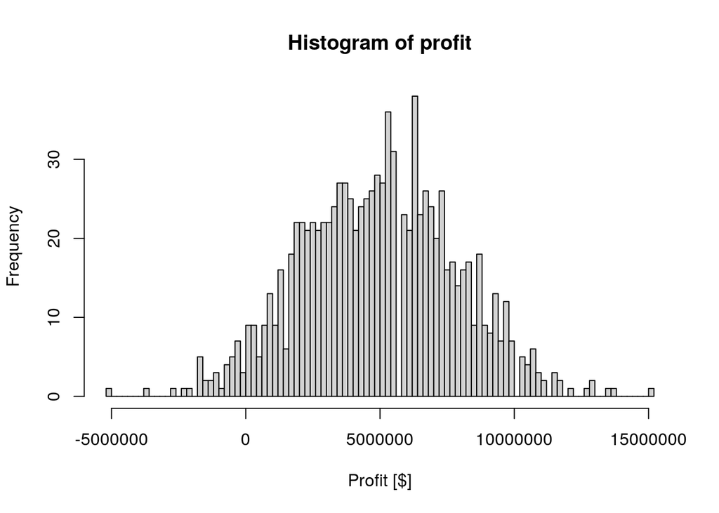

Os resultados parecem ser distribuídos normalmente. Vamos plotar a distribuição normal no mesmo gráfico para confirmar essa hipótese.

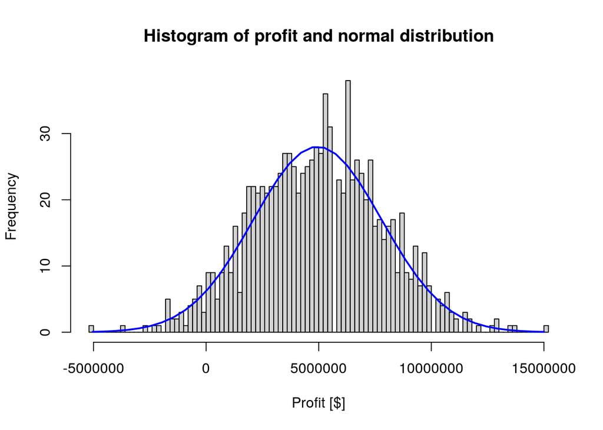

Graficamente, vemos que os dois gráficos são semelhantes. Para provar que nosso lucro segue uma distribuição normal, devemos usar um ** qqplot ** que compara os quantis de nossa distribuição de lucro e os quantis da distribuição normal. Se observarmos que a curva segue uma linha reta, significa que há uma correlação clara entre as duas distribuições.

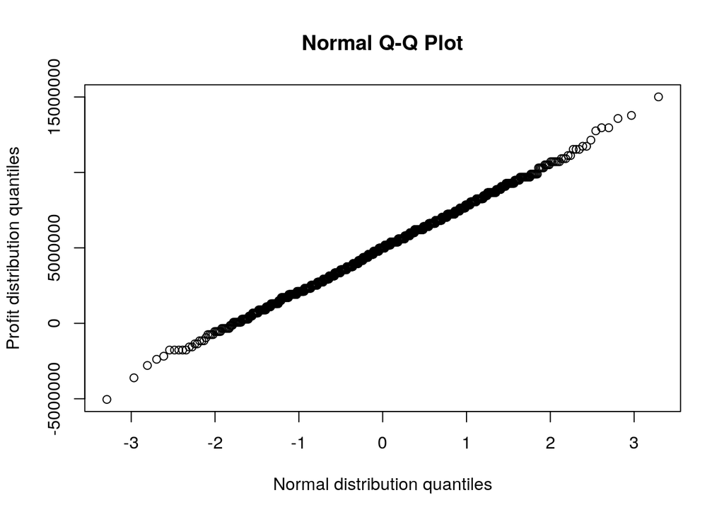

Dado que nossa distribuição de lucro parece normal, podemos calcular o quinto quantil, que deve ser próximo a 0. Isso significa que 5% de todos os resultados estão abaixo de 0 (O banco perde dinheiro apenas 5% de vezes).

```
## [1] "5th Quantile: "
```

```
## [1] 0.04123403
```

O quantil resultante é próximo a 0, o que significa que nossa hipótese estava correta. Vamos visualizar esse resultado no histograma.

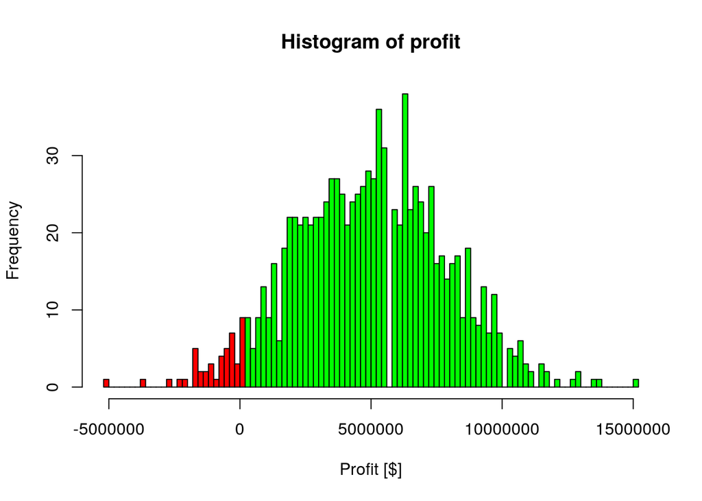

A área em vermelho representa 5% de todos os resultados. Podemos visualizar que o final desta área corresponde ao ponto ** $ 0 ** no eixo X. Isso significa que aqueles casos em que o banco perde dinheiro (Lucro <0), representam apenas 5% de todos os cenários.

# Conclusões

Neste exercício demonstramos o quão prático é o método de Monte Carlo quando precisamos encontrar a probabilidade de ocorrência de um evento, pois ele pode nos economizar muito tempo em cálculos. No entanto, é sempre importante aproveitar a probailidade para testar nossos resultados ou pelo menos estar atentos ao que estamos fazendo.

Em relação ao banco e suas taxas de juros, observamos como uma variação mínima na taxa de juros pode afetar drasticamente os retornos do banco e o risco de perder dinheiro. Por outro lado, devemos levar em consideração que o banco não pode aumentar os juros muito altos porque os clientes iriam para outro banco. Essa situação leva ao questionamento ** O que o banco pode fazer para ganhar mais dinheiro e reduzir as chances de perdê-lo, sem aumentar a taxa de juros? ** A resposta é bastante simples: ** Reduza a taxa de inadimplência! **. Em 2008, se os bancos tivessem prestado mais atenção ao índice de inadimplência, a crise poderia ter sido evitada.